# ReproducibleResearch

## Read in the Data files from the source

```r
Temp <- tempfile()
download.file("https://d396qusza40orc.cloudfront.net/repdata%2Fdata%2Factivity.zip",Temp)
data <- read_delim(unzip(Temp),",",col_types = list(
  steps = col_double(),
  date = col_date(),
  interval = col_double()
))
unlink(Temp)
```

## Problem 1: What is mean total number of steps taken per day?

### Problem 1 - Step 1:

Calculate the total number of steps taken per day

```r
data.p1s1 <- data %>%
  group_by(date) %>%
  summarise(TotalSteps = sum(steps,na.rm = T), .groups = "drop")
```

### Problem 1 - Step 2:

Make a histogram of the total number of steps taken each day

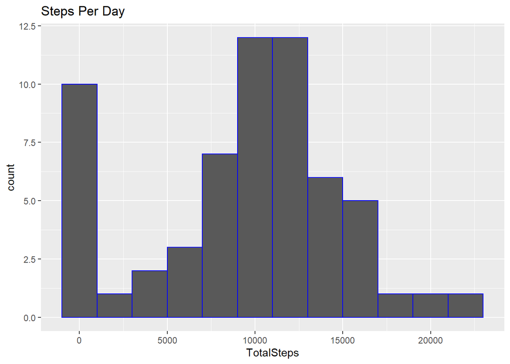

### Problem 1 - Step 3:

Calculate and report the mean and median of the total number of steps taken per day

```
##   DailyMean DailyMedian
## 1   9354.23       10395
```

## Problem 2: What is the average daily activity pattern?

### Problem 2 - Step 1:

Determine the Average steps for each interval

```r
data.p2s1 <- data %>%
  group_by(interval) %>%
  summarise(Ave_Interval_Steps = mean(steps,na.rm = T), .groups = "drop")
```

Make a time series plot (type = "l") of the 5-minute interval (x-axis) and the average number of steps taken, averaged across all days (y-axis)

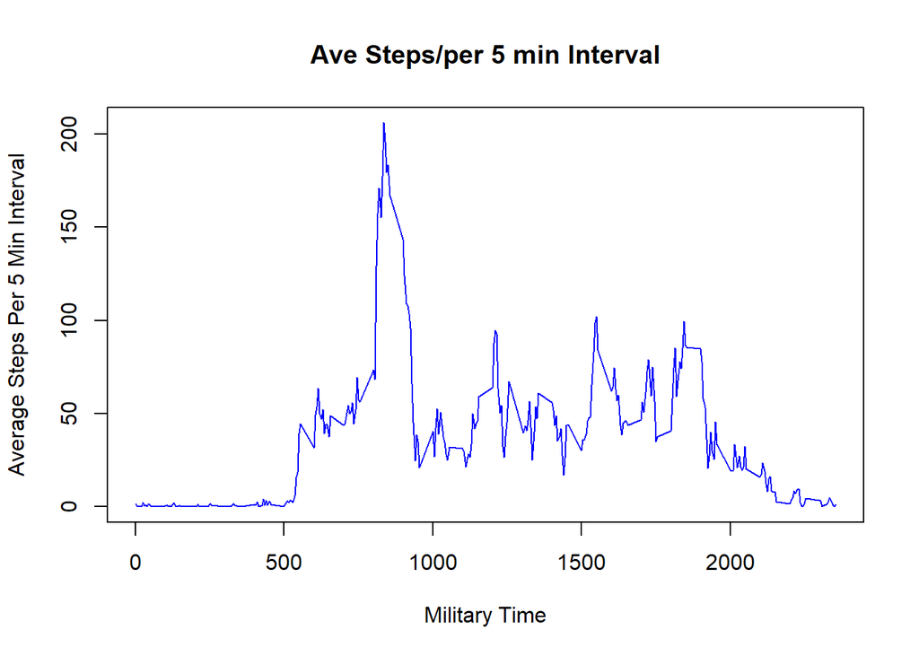

### Problem 2 - Step 2:

Which 5-minute interval, on average across all the days in the dataset, contains the maximum number of steps?

```r
data.p2s1[which.max(data.p2s1$Ave_Interval_Steps),]
```

```
## # A tibble: 1 x 2
##   interval Ave_Interval_Steps
##      <dbl>              <dbl>
## 1      835               206.
```

## Problem 3: Imputing missing values

### Problem 3 - Step 1:

Calculate and report the total number of missing values in the dataset (i.e. the total number of rows with NAs

```r
sapply(data,function(x){sum(is.na(x))})
```

```
##    steps     date interval
##     2304        0        0
```

### Problem 3 Step 2:

Replace the NAs with the average steps for the interval/day

### Problem 3 Step 3:

Create a new dataset that is equal to the original dataset but with the missing data filled in.

```r
data.p3s2 <- data %>%
  mutate(day = wday(date)) %>%
  group_by(interval,day) %>%
  mutate(steps = ifelse(is.na(steps),mean(steps,na.rm = T),steps)) %>%
  ungroup() %>%
  select(-day)
```

### Problem 3 Step 4:

Make a histogram of the total number of steps taken each day with and without NA values

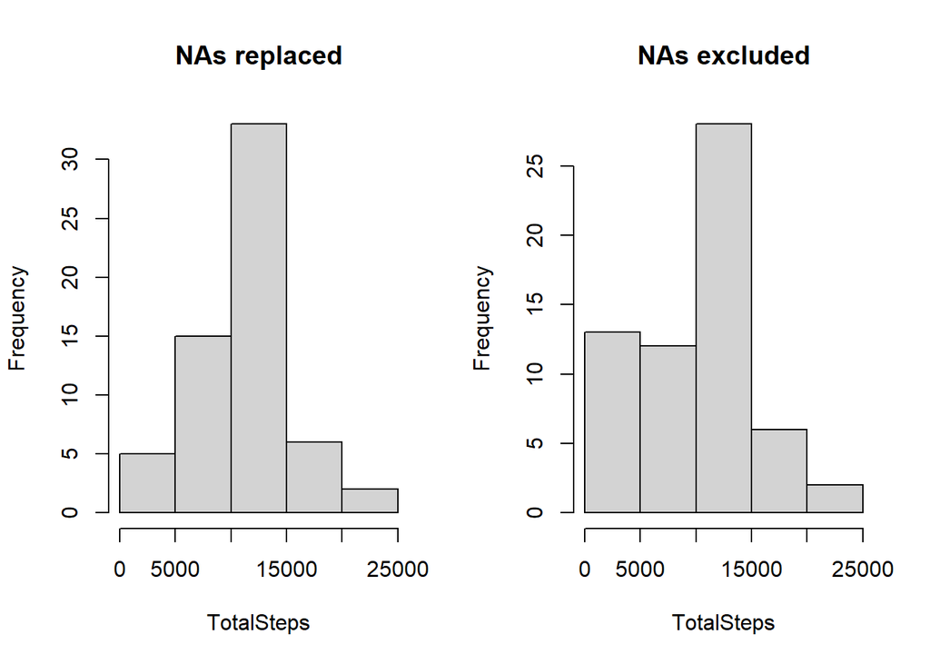

Notice the mean and median total number of steps taken per day increase as a result of imputing missing data on the estimates of the total daily number of steps.

```r
data.p3s4.sum <- data.frame( DailyMean = mean(data.p3s4$TotalSteps),
                         DailyMedian = median(data.p3s4$TotalSteps))
data.p3s4.sum
```

```
##   DailyMean DailyMedian
## 1  10821.21       11015
```

```r
data.p1s2
```

```
##   DailyMean DailyMedian
## 1   9354.23       10395
```

## Problem 4: Are there differences in activity patterns between weekdays and weekends?

### Problem 4 - Step 1:

Create a new factor variable in the dataset with two levels - "weekday" and "weekend" indicating whether a given date is a weekday or weekend day.

```r
data.p4s1 <- data.p3s2 %>%
  mutate(weekend = factor(
    ifelse(weekdays(date)
           %in% c("Saturday","Sunday")
           ,"Weekend"
           ,"Weekday")))
```

## Problem 4 - Step 2:

Make a panel plot containing a time series plot (i.e.type = "l") of the 5-minute interval (x-axis) and the average number of steps taken, averaged across all weekday days or weekend days (y-axis). See the README file in the GitHub repository to see an example of what this plot should look like using simulated data.

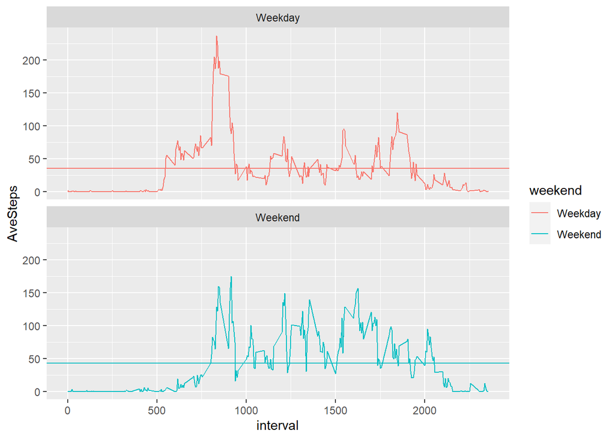

```r
data.p4s2 <-data.p4s1 %>%
  group_by(weekend) %>%
  mutate(TotalAve = mean(steps))%>%
  group_by(interval, weekend,TotalAve) %>%
  summarise(AveSteps = mean(steps), .groups = "drop")

ggplot(data = data.p4s2, mapping = aes(x = interval, y = AveSteps, color = weekend)) +
  geom_line() +
  geom_hline(mapping = aes(yintercept = TotalAve, color = weekend))+
  facet_wrap(~weekend,nrow = 2)
```